# TCGA Analysis

J Stofel

July 21, 2015

# Introduction

We use data in The Cancer Genome Atlas [(TCGA)](https://tcga-data.nci.nih.gov/tcga/) and the [Tumor Portal](http://www.tumorportal.org/) to look for genes with cancer-related mutations to see if there are identifiable patters of co-expression or mutual exclusivity.

# Data and Methods

## TCGA data

```r
   load("homework.Rdata")
   ls()
```

```
##  [1] "BRCAreceptorStatus"       "clinicData"
##  [3] "geneNamesByAssay"         "methyData"
##  [5] "methyGenomeAnnotation"    "methySampleAnnotation"
##  [7] "methySymbols"             "methyTissueAnnotations"
##  [9] "rnaSeq2Data"              "rnaSeq2GenomeAnnotation"
## [11] "rnaSeq2SampleAnnotation"  "rnaSeq2Symbols"
## [13] "rnaSeq2TissueAnnotations" "SARChistologicalType"
## [15] "snp6Data"                 "snp6GenomeAnnotation"
## [17] "snp6SampleAnnotation"     "snp6Symbols"
## [19] "snp6TissueAnnotations"    "UCEChistologicalType"
```

## Mutation data

This data is from the [Tumor Portal](http://www.tumorportal.org/). It was downloaded to a text file 21 July 2015. Since this is a large file, it takes a while to load. To save time while creating and debugging this file, a copy was saved as Rdata binary, which can be loaded a bit more quickly.

```r
if (file.exists("saved_panCanMut.Rdata")) {
  load("saved_panCanMut.Rdata")
} else {
  panCanMut <-
             read.table("PanCan.maf", header=TRUE, sep="\t",
             stringsAsFactors = FALSE)
   save(panCanMut, file = "saved_panCanMut.Rdata")
}
```

The Pan Cancer mutations file has 11 variables (columns) and 845987 records (rows).

```r
   colnames(panCanMut)
```

```
##  [1] "ttype"          "patient"        "gene"           "classification"
##  [5] "type"           "chr"            "pos"            "ref_allele"
##  [9] "newbase"        "context65"      "cons46"
```

```r
   panCanMut[1:3,]
```

```
##   ttype patient    gene classification            type chr       pos
## 1  BRCA BR-0001 PRAMEF4            SNP      Synonymous   1  12942094
## 2  BRCA BR-0001     IVL            SNP        Missense   1 152883016
## 3  BRCA BR-0001  ZBTB37            DEL Splice_Site_Del   1 173837392
##   ref_allele newbase context65 cons46
## 1          G       A        37     48
## 2          A       G         7     52
## 3      AGGCA       -        11     51
```

Each row in the file represents a single mutation . We will look at a few genes of interest. For example, PTEN (Phosphatase and tensin homolog) is a tumor suppressor. Mutations in this gene that cause it to malfunction will lead to many different cancers.

```r
 ptenMut <- panCanMut[panCanMut[,"gene"]=="PTEN", ]
 dim(ptenMut)
```

```
## [1] 500  11
```

```r
 ptenMut[1:3,]
```

```
##      ttype    patient gene classification              type chr      pos
## 1423  BRCA    BR-0041 PTEN            SNP Missense_Mutation  10 89692871
## 2583  BRCA BR-MEX-050 PTEN            SNP       Splice_site  10 89653784
## 2584  BRCA BR-MEX-050 PTEN            DEL   Frame_Shift_Del  10 89692949
##      ref_allele newbase context65 cons46
## 1423          G       T        48     96
## 2583          A       T        16     86
## 2584          T       -        52     88
```

What are the types of mutations? All types are bad except for the ones labeled “Silent”. Note, however, that if you want to look at the different types in more detail, you will need to be aware of and correct for the labeling inconsistencies. For example, Splice_site vs Splice_Site and Missense vs Missense_Mutation.

```r
  table(ptenMut[, "type"])
```

```
##
##        Frame_Shift_Del        Frame_Shift_Ins           In_Frame_Del
##                     93                     31                     13
##           In_Frame_Ins               Missense      Missense_Mutation
##                      1                      3                    211
##               Nonsense      Nonsense_Mutation                 Silent
##                      1                     96                      7
##            Splice_site            Splice_Site        Splice_Site_SNP
##                     11                     30                      2
## Translation_Start_Site
##                      1
```

And Keith gives an example of uncleaned clincial data re Taxol and all the name variations (generic vs brand name and misspellings thereof).

Another question: Is 500 “a lot” of mutations? Look at your list of “top mutated” genes and the Tumor Portal list of “top mutated” genes. Are they the same? You have TTN as a “top mutated” gene but Tumor Portal does not - why not?

Look at the genes in GeneCards website to get more info about the specific genes. For example, TTN gene. This is colloqually known as “Titan”. It is 300 kb long (very large). So note that the absolute number of mutations is less important than the ratio of mutations to the size of the gene…

Also, be aware of whether you are looking at number of mutations in a gene or number of patients with mutations in a gene (some patients can have < 1 mutation in a given gene).

```r
 # Size of matrix
 length(rnaSeq2Data)
```

```
## [1] 249275
```

```r
 # Rows by columns
 dim(rnaSeq2Data)
```

```
## [1]   25 9971
```

```r
 # Row names
 rownames(rnaSeq2Data)
```

```
##  [1] "APC"         "ARID1A"      "ATM"         "BRAF"        "CDKN2A"
##  [6] "CREBBP"      "EGFR"        "FAT1"        "KMT2C"       "KMT2D"
## [11] "KRAS"        "MTOR"        "NF1"         "NOTCH1"      "PBRM1"
## [16] "PIK3CA"      "PIK3R1"      "PTEN"        "RB1"         "SETD2"
## [21] "SMARCA4"     "SPEN"        "TP53"        "VHL"         "FBXW7|55294"
```

```r
 # Column names
 cnames <- colnames(rnaSeq2Data)
 cnames[1:3]
```

```
## [1] "TCGA-OR-A5J1-01A-11R-A29S-07" "TCGA-OR-A5J2-01A-11R-A29S-07"
## [3] "TCGA-OR-A5J3-01A-11R-A29S-07"
```

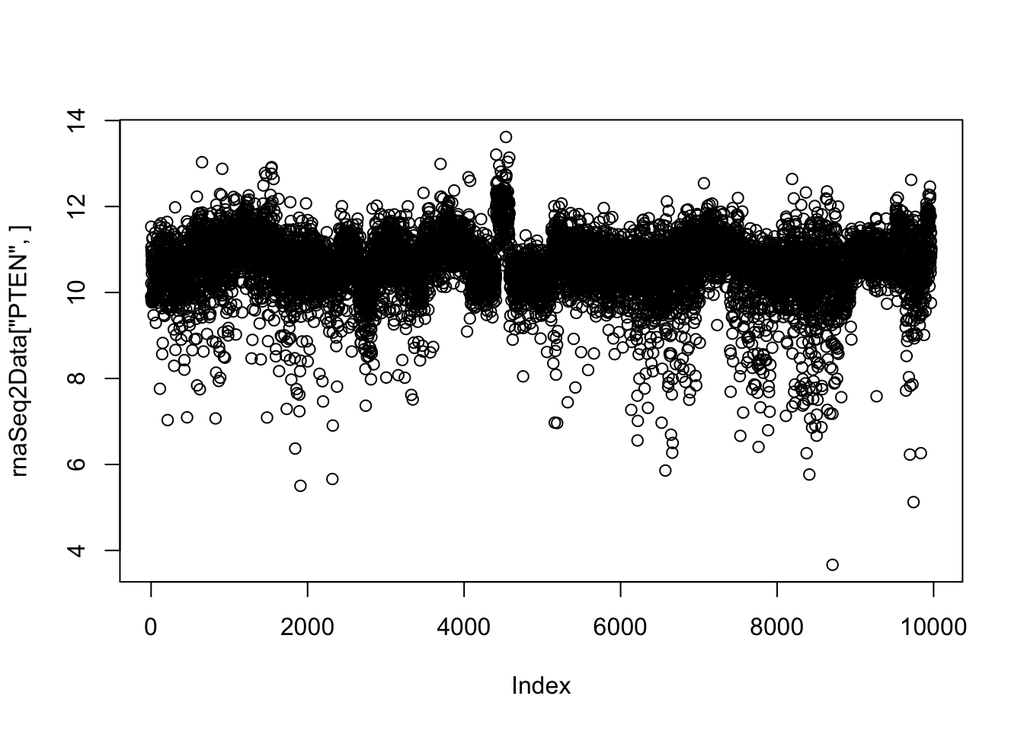

```r
 #rnaSeq2Data["PTEN",]
 plot(rnaSeq2Data["PTEN",])
```

The above is too big - try again looking at just first 1000 patients

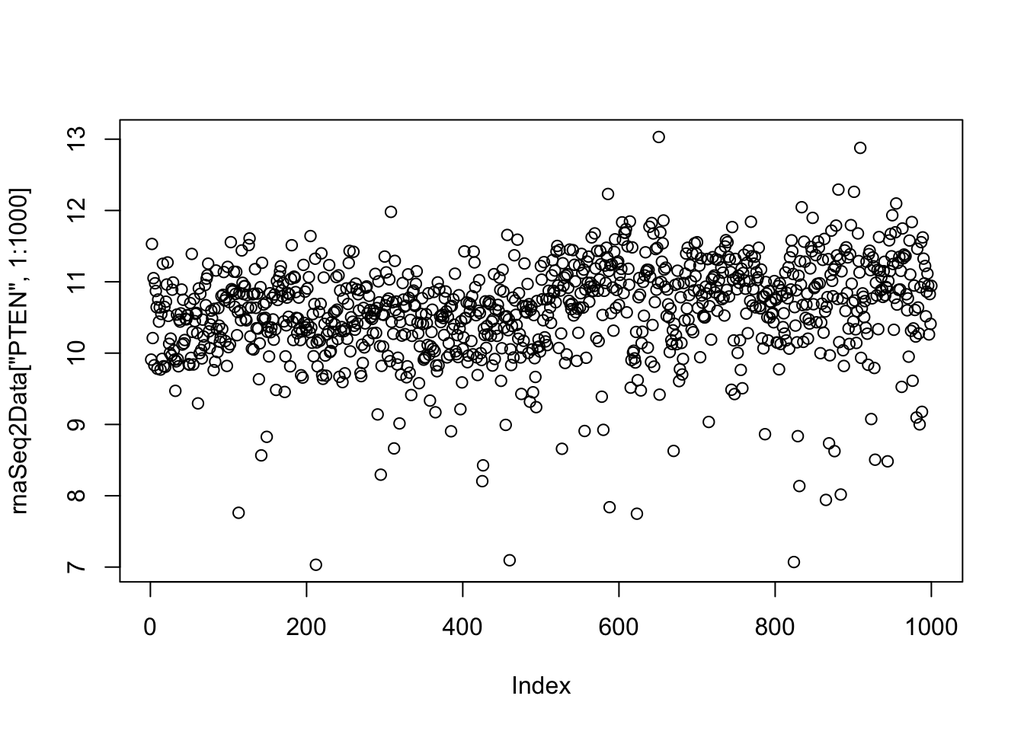

```r
 plot(rnaSeq2Data["PTEN",1:1000])
```

What about the specific thing going on between 4000 and 6000?

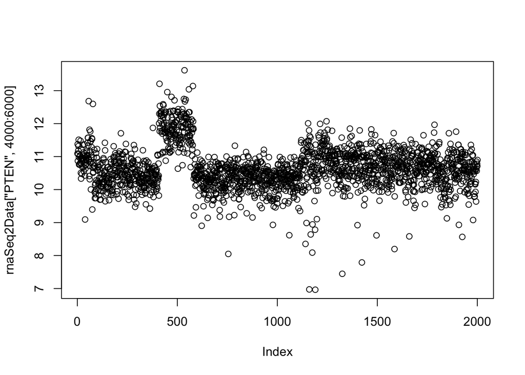

```r
 plot(rnaSeq2Data["PTEN",4000:6000])
```

Here’s a more detailed look, but how would we find out what is going on here? Appears to be a run of patients that are “noticeably” different than the rest. Are they really different? If so, why?

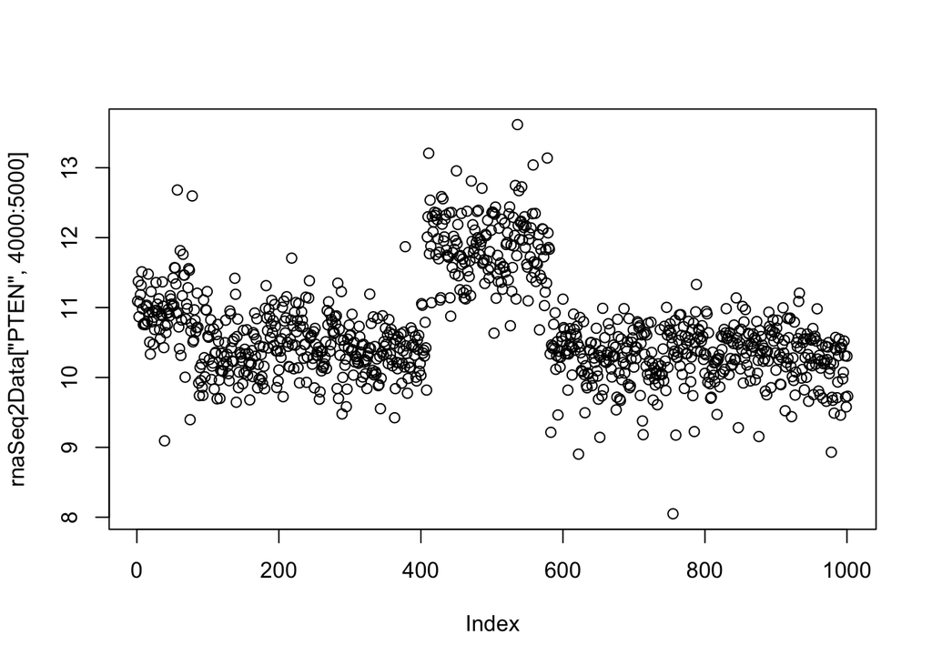

```r
 plot(rnaSeq2Data["PTEN",4000:5000])
```

Now look at the data another way. What if we have decided that the issue above is a data problem, and we want to take a step back look at the data without focussing on that - what if we sample the data a different way?

Try a different method – thin the data systematically by sampling patients 1-20000 by 10s (you get a sample of 2000).

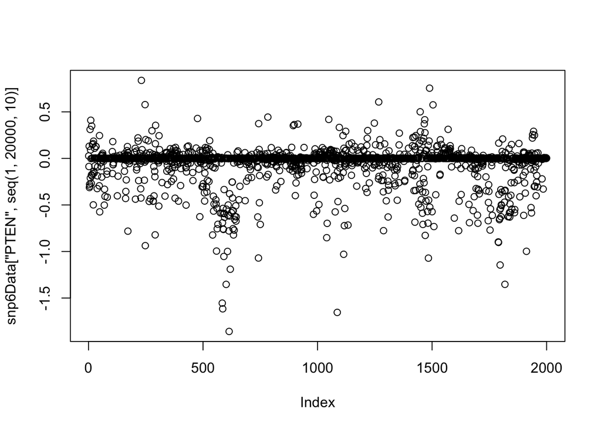

```r
 plot(snp6Data["PTEN", seq(1,20000,10)])
```

This is still not the best sampling, as we are systematically sampling from an ordered list (ordered by patient characteristics). Try a random sample of 2000 patients selected from the first 20000. We set the seed for randomizing, so the random sample is reproducible.

```r
 set.seed(3)
 rnorm(10)
```

```
##  [1] -0.96193342 -0.29252572  0.25878822 -1.15213189  0.19578283
##  [6]  0.03012394  0.08541773  1.11661021 -1.21885742  1.26736872
```

```r
 sample(1:20000,2000)
```

[output not shown]

[output cut: 167 more lines]

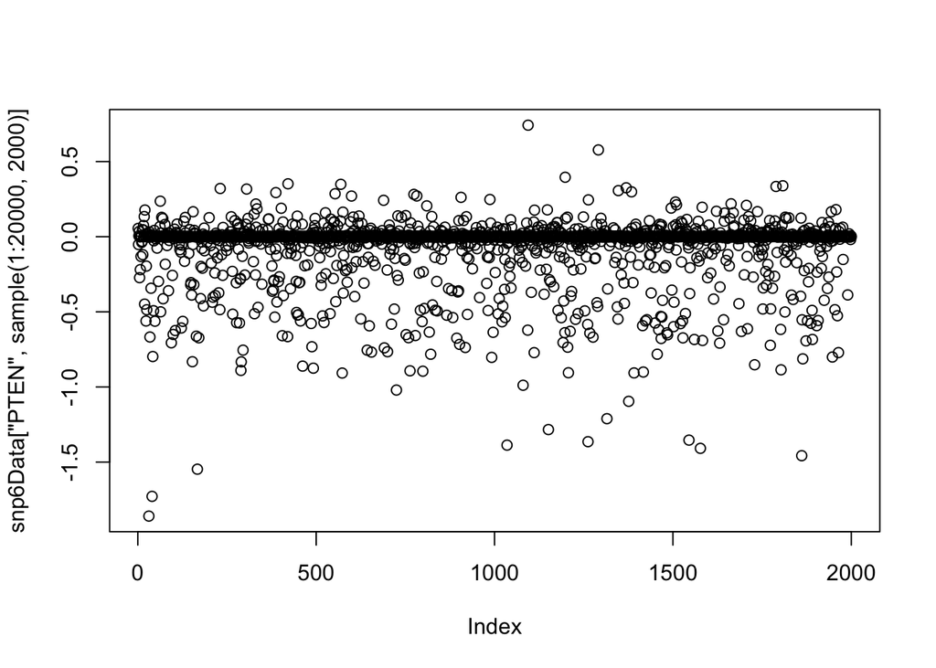

```r
 plot(snp6Data["PTEN", sample(1:20000,2000)])
```

Copy number is in the snp6 data….

Who has PTEN mutations? (what patients)

```r
 ptenMutNames <- substr(ptenMut[,"patient"], 1, 12)
 ptenMutNames <- unique(ptenMutNames)
 ptenMutNames <- ptenMutNames[substr(ptenMutNames,1,4) == "TCGA"]
 length(ptenMutNames)
```

```
## [1] 344
```

```r
 matchedToMut <- match(ptenMutNames, substr(colnames(snp6Data),1,12))
```

The pancan mutation table lists all mutations and this can include cases where same gene is mutated more than once in a given person. we need to match pten copy number and mutation data by sample name.

we need to exlcude multiple matches

we want to check for co-occurrence / mutual exclusivity by tissue type to check for associations.

we can do this with Fisher’s exact tests with loss CN < -0.5.

### Session Information

```r
#This file was run in the following location:
getwd()
```

```
## [1] "/Users/susanfuller/Downloads/Module5-master/TCGA"
```